# P1: Latent Variable Reduction

Brandon Bergsneider

2/11/2022

### Analyzing the MDASI-BT data for 1128 PBT patients, this script identifies redundant variables

### and consolidates them into latent variables using the Unique Variable Analysis method described in Christensen, Garrido, & Golino (PsyArXiv)

```r
# Load packages
library('EGAnet')
library("dplyr")
```

```r
library("tidyr")
library("qgraph")
library("ggplot2")
library("reshape2")
library(readr)

orange="#ff7f00"
green="#4caf4a"
red="#e4211c"
blue="#387db8"
```

```r
# Load data
symptom_data <- read_csv('data/Merged_SymptomSeverity_Upload_Final.csv')
```

```r
# Create dataframe for symptom data from all patients
all_symptom_data <- dplyr::select(symptom_data, -Study, -ID)
```

```r
# Function for constructing a GGM regularized using EBICglasso method
# All variables considered continuous
# If covariance matrix is nonpositive definite, matrix is forced to be nonpositive definite using the nearPD function
# Input variables:
# - data: dataframe of symptom severity data to analyze
# - npn: boolean representing whether or not to consider data as nonparanormal (not continuous)
construct_network <- function(data, npn=FALSE) {
  cor_matrix <- cor_auto(data, detectOrdinal=FALSE, forcePD=TRUE, npn.SKEPTIC=npn)
  GLASSO_matrix <- EBICglasso(cor_matrix, nrow(data), 0.5)
  network <- qgraph(GLASSO_matrix, layout = "spring")
  return(network)
}
```

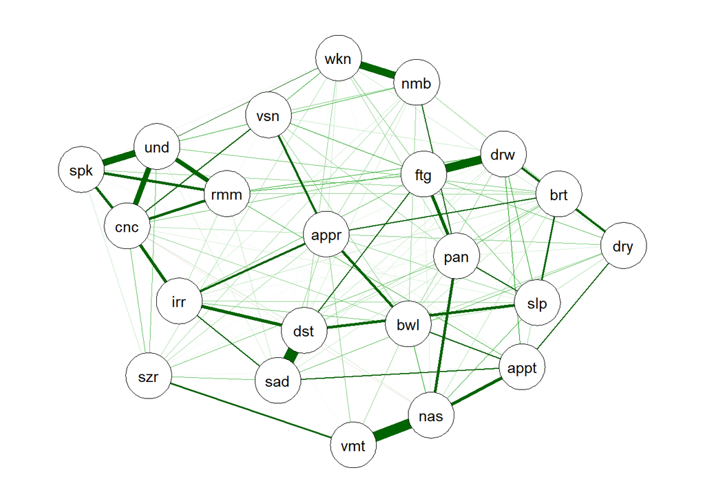

```
## From     To  Weight
## 1     ---     2   0.19
## 1     ---     3   0.17
## 2     ---     3   0.01
## 1     ---     4   0.12
## 2     ---     4   0.07
## 3     ---     4   0.09
## 1     ---     5   0.03
## 2     ---     5   0.12
## 3     ---     5   0.02
## 4     ---     5   0.17
## 1     ---     6   0.08
## 3     ---     6   0.03
## 4     ---     6   0.13
## 5     ---     6   0.04
```

[output cut: 113 more lines]

```r
# Construct a GGM from the original symptom data to see which variables are highly correlated
construct_network(all_symptom_data)
```

### From visual inspection, the symptom pairs vmt-nas, sad-dst, wkn-nmb, and ftg-drw all appear highly correlated and may be redundant

### Lets look at the severity and occurrence distributions of each variable to determine which variables may be redundant

### Although not established in network analysis, Exporatory Factor Analysis (EFA) methods commonly remove symptoms present

### in <20% or >80% of patients in order to have sufficient variation and covariation in the data

```r
tmp_all_symptom_data <- all_symptom_data
tmp_all_symptom_data['comm'] <- 1
long_all_symptom_data <- melt(tmp_all_symptom_data, id='comm')
```

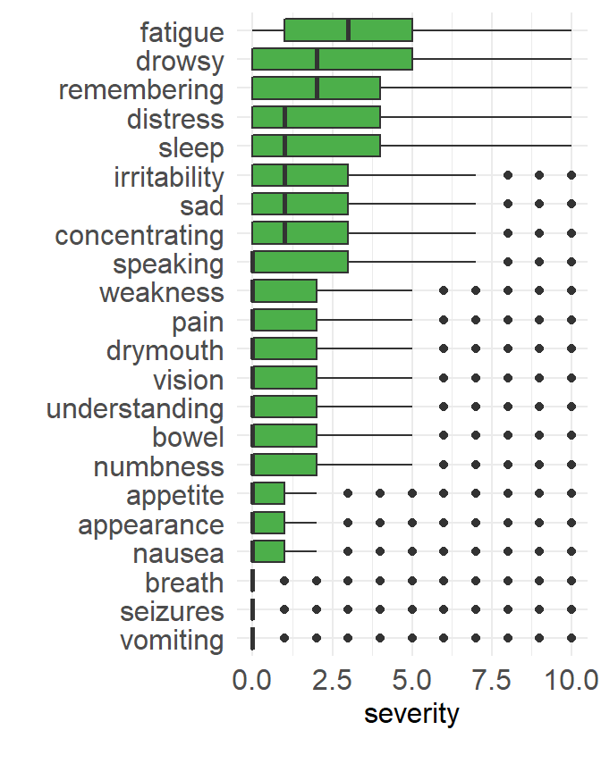

```r
severity_plot <- ggplot(long_all_symptom_data, aes(x=reorder(variable,value), y=value)) + geom_boxplot(fill=green)  + ylab('severity\n') + xlab('') + theme_minimal() + coord_flip() + theme(axis.text = element_text(size = 12), axis.title = element_text(size = 12))
severity_plot
```

```r
#ggsave('images/severity_plot.png', plot = severity_plot, width = 8, height = 5)
```

```r
tmp_all_symptom_data <- all_symptom_data
frequency_all <- round(colSums( tmp_all_symptom_data != 0)/nrow(tmp_all_symptom_data)*100,1)
frequency_df <- data.frame(symptom=names(frequency_all), frequency=unname(frequency_all))
frequency_df
```

```
##          symptom frequency
## 1           pain      40.9
## 2        fatigue      78.5
## 3         nausea      25.8
## 4          sleep      60.2
## 5       distress      60.5
## 6         breath      23.8
## 7    remembering      67.5
## 8       appetite      32.0
## 9         drowsy      70.9
## 10      drymouth      43.8
## 11           sad      52.0
## 12      vomiting       8.7
## 13      numbness      33.6
## 14      weakness      38.3
## 15 understanding      41.3
## 16      speaking      48.3
## 17      seizures      12.1
## 18 concentrating      56.6
## 19        vision      43.6
## 20    appearance      32.0
## 21         bowel      36.0
## 22  irritability      56.9
```

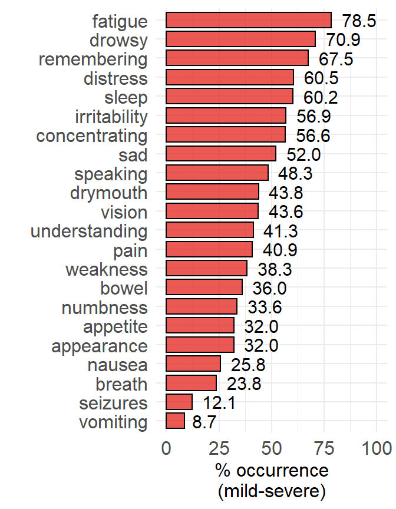

```r
frequency_plot <- ggplot(data=frequency_df, aes(x=reorder(symptom,frequency),y=frequency)) + geom_bar(stat="identity", color='black', fill=red, alpha=0.75, width=0.8) + ylab('% occurrence\n(mild-severe)') + xlab('') + ylim(0,100) + geom_text(aes(label=sprintf("%.1f",frequency)),hjust=-0.3, size=4) + theme_minimal() + coord_flip() + theme(axis.text = element_text(size = 12), axis.title = element_text(size = 12))

frequency_plot
```

```r
#ggsave('images/mild_frequency_plot.png', plot = frequency_plot, width = 8, height = 5)
```

```r
tmp_all_symptom_data <- all_symptom_data
frequency_severe <- round(colSums( tmp_all_symptom_data > 4)/nrow(tmp_all_symptom_data)*100,1)
severe_frequency_df <- data.frame(symptom=names(frequency_severe), frequency= unname(frequency_severe))
severe_frequency_df
```

```
##          symptom frequency
## 1           pain      14.9
## 2        fatigue      35.9
## 3         nausea       7.8
## 4          sleep      21.5
## 5       distress      21.3
## 6         breath       4.9
## 7    remembering      23.3
## 8       appetite      11.0
## 9         drowsy      25.5
## 10      drymouth      14.3
## 11           sad      15.7
## 12      vomiting       3.2
## 13      numbness      11.1
## 14      weakness      16.0
## 15 understanding      11.5
## 16      speaking      15.9
## 17      seizures       5.1
## 18 concentrating      14.8
## 19        vision      14.1
## 20    appearance       8.7
## 21         bowel      11.6
## 22  irritability      17.3
```

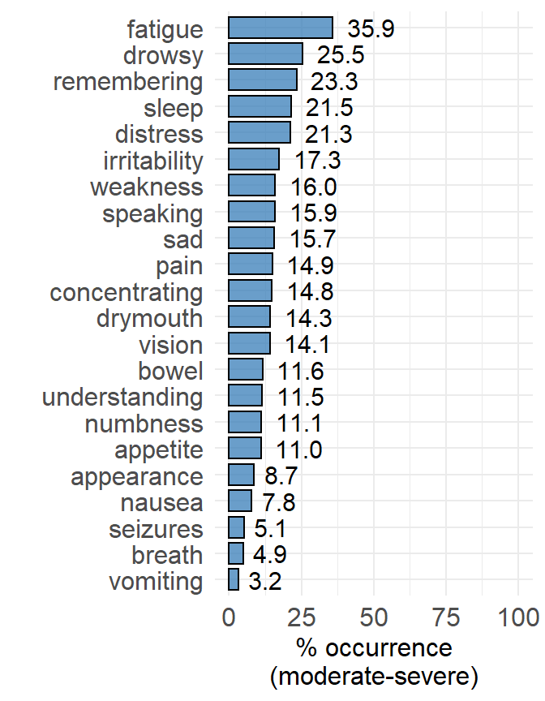

```r
severe_frequency_plot <- ggplot(data=severe_frequency_df, aes(x=reorder(symptom,frequency),y=frequency)) + geom_bar(stat="identity", color='black', fill=blue, alpha=0.75, width=0.8) + ylab('% occurrence\n(moderate-severe)') + xlab('') + ylim(0,100) + geom_text(aes(label=sprintf("%.1f",frequency)),hjust=-0.3, size=4) + theme_minimal() + coord_flip() + theme(axis.text = element_text(size = 12), axis.title = element_text(size = 12))
severe_frequency_plot
```

```r
#ggsave('images/severe_frequency_plot.png', plot = severe_frequency_plot, width = 8, height = 5)
```

### Based on the symptom severity and occurrence distributions, it seems that vomiting (present in 9% of pts) and fatigue (present in 79% of pts)

### might be good variables to consolidate

### Next, perform Unique Variable Analysis (UVA) to consolidate redundant variables

```r
# Perform manual UVA (latent variable)
data.manual <- UVA(data = all_symptom_data, auto = FALSE)
saveRDS(data.manual, "data/uvaResults.RDS")
```

### After UVA, redundant variables with both topological and conceptual overlap were combined into latent variables

### Five redundant pairs were identified by UVA: vmt-nas, sad-dst, wkn-nmb, ftg-drw, and und-spk

### However, only vmt-nas and ftg-drw were combined into latent variables because they had substantial conceptual overlap

### Furthermore, as noted above, vomiting and fatigue are good variables to consolidate because

### of their low and high occurrence rates, respectively

```r
data.manual <- readRDS("data/uvaResults.RDS")
# Check wTO between all pairs of variables
data.manual$redundancy$descriptives
```

```
## $basic
##      Mean    SD Median   MAD 3*MAD 6*MAD Minimum Maximum Critical Value
## wTO 0.045 0.057  0.027 0.016 0.048 0.096   0.001   0.408           0.25
##
## $centralTendency
##                                wTO SD from Mean MAD from Median
## nausea--vomiting             0.408        6.369          23.812
## distress--sad                0.368        5.668          21.313
## understanding--speaking      0.301        4.493          17.125
## fatigue--drowsy              0.275        4.037          15.500
## numbness--weakness           0.268        3.915          15.063
## understanding--concentrating 0.218        3.038          11.938
## remembering--understanding   0.206        2.828          11.188
## speaking--concentrating      0.189        2.530          10.125
## remembering--speaking        0.180        2.372           9.563
## remembering--concentrating   0.168        2.162           8.813
## distress--irritability       0.163        2.074           8.500
## nausea--appetite             0.129        1.478           6.375
## drowsy--drymouth             0.129        1.478           6.375
## pain--fatigue                0.127        1.443           6.250
## sad--irritability            0.126        1.425           6.188
## appearance--bowel            0.123        1.373           6.000
## vision--appearance           0.120        1.320           5.813
## concentrating--irritability  0.119        1.303           5.750
## sleep--distress              0.118        1.285           5.688
## pain--nausea                 0.110        1.145           5.188
## appearance--irritability     0.098        0.935           4.438
## vomiting--seizures           0.096        0.900           4.313
## pain--sleep                  0.095        0.882           4.250
## sleep--breath                0.094        0.865           4.188
## appetite--bowel              0.091        0.812           4.000
## fatigue--sleep               0.089        0.777           3.875
## appetite--drymouth           0.087        0.742           3.750
## fatigue--drymouth            0.083        0.672           3.500
## nausea--bowel                0.083        0.672           3.500
## breath--appearance           0.083        0.672           3.500
## concentrating--vision        0.081        0.637           3.375
## weakness--vision             0.079        0.602           3.250
## fatigue--distress            0.078        0.584           3.188
## pain--numbness               0.075        0.531           3.000
```

[output cut: 180 more lines]

```
## vomiting--numbness           0.005       -0.696          -1.375
## vomiting--irritability       0.005       -0.696          -1.375
## speaking--bowel              0.005       -0.696          -1.375
## fatigue--vomiting            0.004       -0.713          -1.438
## distress--speaking           0.004       -0.713          -1.438
## vomiting--concentrating      0.004       -0.713          -1.438
## pain--speaking               0.003       -0.731          -1.500
## nausea--concentrating        0.003       -0.731          -1.500
## drymouth--speaking           0.003       -0.731          -1.500
## vomiting--weakness           0.003       -0.731          -1.500
## appetite--weakness           0.002       -0.748          -1.563
## drowsy--vomiting             0.002       -0.748          -1.563
## drymouth--vomiting           0.002       -0.748          -1.563
## vomiting--speaking           0.002       -0.748          -1.563
## remembering--vomiting        0.001       -0.766          -1.625
```

```r
# Check wTO between all pairs of variables
wTO_df <- data.frame(data.manual$redundancy$descriptives$centralTendency)
wTO_df <- cbind(pair = rownames(wTO_df), wTO_df)
rownames(wTO_df) <- 1:nrow(wTO_df)
head(wTO_df,10)
```

```
##                            pair   wTO SD.from.Mean MAD.from.Median
## 1              nausea--vomiting 0.408        6.369          23.812
## 2                 distress--sad 0.368        5.668          21.313
## 3       understanding--speaking 0.301        4.493          17.125
## 4               fatigue--drowsy 0.275        4.037          15.500
## 5            numbness--weakness 0.268        3.915          15.063
## 6  understanding--concentrating 0.218        3.038          11.938
## 7    remembering--understanding 0.206        2.828          11.188
## 8       speaking--concentrating 0.189        2.530          10.125
## 9         remembering--speaking 0.180        2.372           9.563
## 10   remembering--concentrating 0.168        2.162           8.813
```

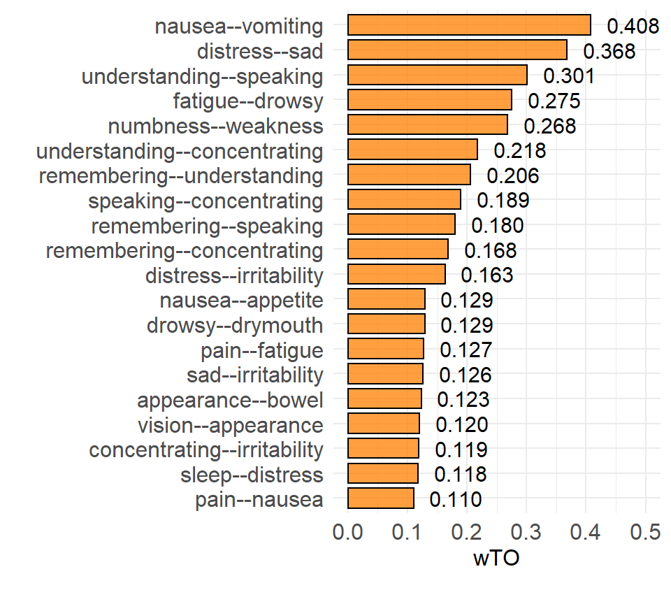

```r
wTO_plot <- ggplot(data=head(wTO_df,20), aes(x=reorder(pair,wTO),y=wTO)) + geom_bar(stat="identity", color='black', fill=orange, alpha=0.75, width=0.8) + ylab('wTO\n') + xlab('') + ylim(0,0.5) + geom_text(aes(label=sprintf("%.3f",wTO)),hjust=-0.3, size=4) + theme_minimal() + coord_flip() + theme(axis.text = element_text(size = 12), axis.title = element_text(size = 12))
wTO_plot
```

```r
#ggsave('images/wTO_plot.png', plot = wTO_plot, width = 8, height = 5)
```

```r
# Save reduced data in a new dataframe
reduced_all_symptom_data <- data.manual$reduced$data

# Latent variable reduction yields variable values that are not between 0 and 10
# In order to keep latent variable values consistent with other variables, latent variable
# values were normalized to be between 0 and 10
for(lv in list('fatigue-drowsy','nausea-vomiting')) {
  reduced_all_symptom_data[,lv] <- (reduced_all_symptom_data[,lv]-min(reduced_all_symptom_data[,lv]))/(max(reduced_all_symptom_data[,lv])-min(reduced_all_symptom_data[,lv]))*10
}
```

```r
library(ggridges)
```

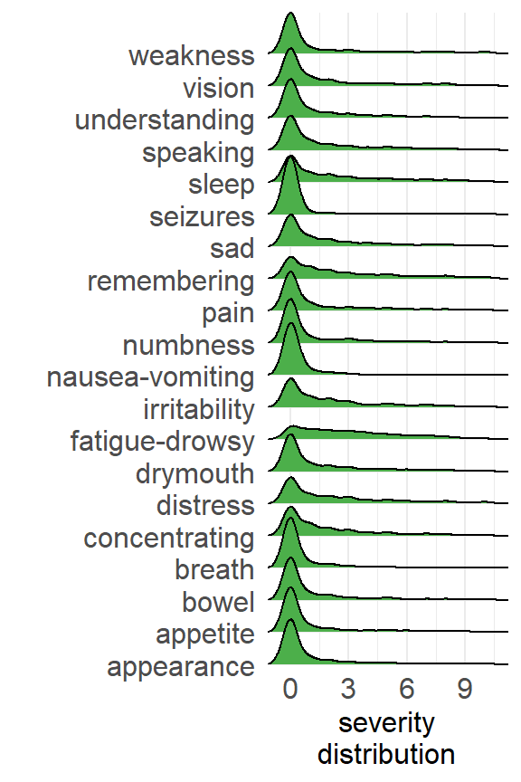

```r
reduced_all_symptom_data_long <- reduced_all_symptom_data %>% data.frame() %>% pivot_longer(everything(), names_to = "symptom", values_to="severity") %>% rowwise() %>% mutate(symptom=gsub("\\.","-", symptom))

density_plot <- ggplot(reduced_all_symptom_data_long, aes(x=severity, y=symptom)) + geom_density_ridges(fill='#4caf4a')  + xlab('severity\ndistribution') + ylab('') + theme_minimal() + theme(axis.text = element_text(size = 12), axis.title = element_text(size = 12)) +
  scale_y_discrete(expand = c(0, 0)) +
  scale_x_continuous(expand = c(0, 0)) +
  coord_cartesian(clip = "off")
density_plot
```

```r
apply(reduced_all_symptom_data, 2, shapiro.test)
```

```
## $pain
##
##  Shapiro-Wilk normality test
##
## data:  newX[, i]
## W = 0.6722, p-value < 2.2e-16
##
##
## $`fatigue-drowsy`
##
##  Shapiro-Wilk normality test
##
## data:  newX[, i]
## W = 0.921, p-value < 2.2e-16
##
##
## $`nausea-vomiting`
##
##  Shapiro-Wilk normality test
##
## data:  newX[, i]
## W = 0.40762, p-value < 2.2e-16
##
##
## $sleep
##
##  Shapiro-Wilk normality test
##
## data:  newX[, i]
## W = 0.80787, p-value < 2.2e-16
##
##
## $distress
##
##  Shapiro-Wilk normality test
##
## data:  newX[, i]
## W = 0.80817, p-value < 2.2e-16
##
##
```

[output cut: 103 more lines]

```
##
## $bowel
##
##  Shapiro-Wilk normality test
##
## data:  newX[, i]
## W = 0.6178, p-value < 2.2e-16
##
##
## $irritability
##
##  Shapiro-Wilk normality test
##
## data:  newX[, i]
## W = 0.77692, p-value < 2.2e-16
```

```r
# Check that latent variable normalization does not affect structure of the network
n1 <- construct_network(reduced_all_symptom_data)
```

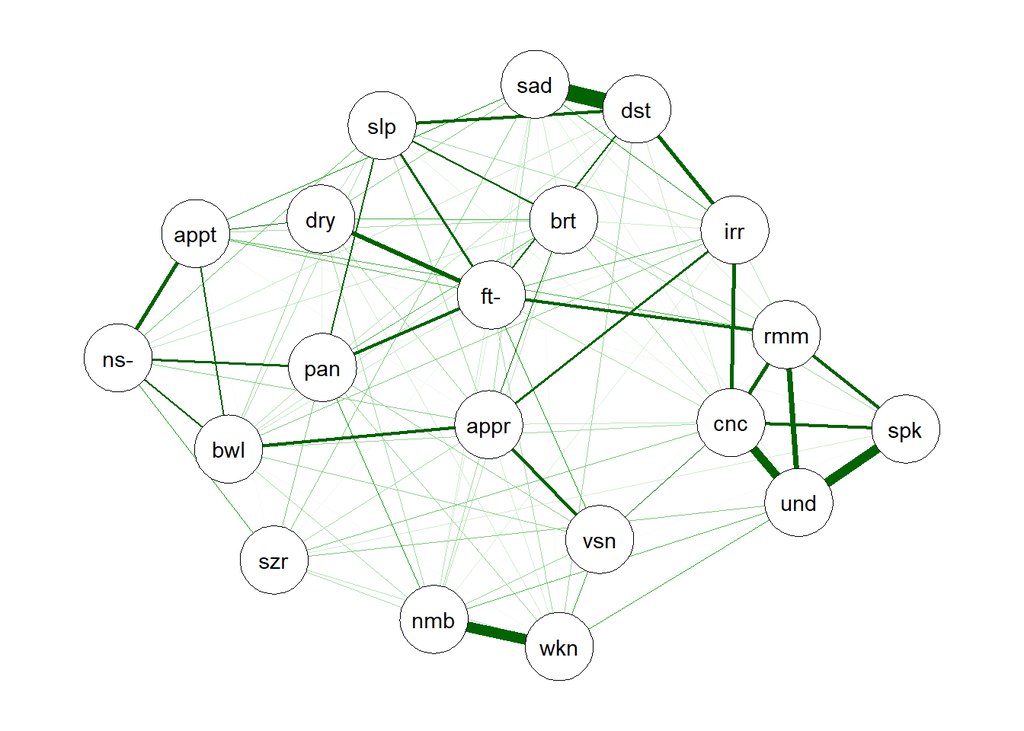

```r
n2 <- construct_network(data.manual$reduced$data)
```

[figure not shown]

```r
# Save reduced symptom dataframe as a csv file
#write.csv(reduced_all_symptom_data, '~/OneDrive-NIH/Unsupervised_Clustering/data/p1_reduced_all_symptom_data.csv', row.names = FALSE)
```